# Does inaugural speeches evolve over time?

Yanjun Lin, YL3829

# Abstract

We want to see does inaugural speeches evolve over time. If so, then how inaugural speech on time scale would be related or different. Will there be a trend of these speeches over time?  
In the exploration below, we applied LSA and LDA and found that the speeches are actually quite relevant with time in the form of latent semanteme and topics clustering. We could see there is trend in the recent speeches from the result of LSA. In the end we also discovered that President Trump’s speech is quite different from his recent predecessors, which also confirms the fact that President Trump has a different background, values, action as well as the way he makes speeches.

# Step 0 - load package

```r
packages_need <- c('xlsx','tm','magrittr','topicmodels','factoextra','Rtsne',
                  'ggplot2','akmeans','shiny','wordcloud','tydytext')

packages_install <- setdiff(packages_need,
                        intersect(installed.packages()[,1],
                                  packages_need))

if(length(packages_install)>0){
  install.packages(packages_install, dependencies = TRUE,
                   repos='http://cran.us.r-project.org')
}

library(xlsx)
library(tm)
library(magrittr)
library(topicmodels)
library(factoextra)
library(Rtsne)
library(ggplot2)
library(akmeans)
library(shiny)
library(wordcloud)
library(tidytext)
```

# Step 1 - Read in the speeches

```r
path <- '../data/InauguralSpeeches/'
speech_list <- read.xlsx('../data/InaugurationInfo.xlsx',sheetIndex = 1)
speech_date <- read.csv('../data/InauguationDates.txt',sep='\t')
speech_list$President <- as.character(tolower(speech_list$President)) # turn all names into lower case
speech_date$PRESIDENT <- as.character(tolower(speech_date$PRESIDENT)) # turn all names into lower case

# Since speech_date and speech_list have some different names format,
# We need to change some of them by hand.
speech_date$PRESIDENT[speech_date$PRESIDENT=='james knox polk'] <- 'james k. polk'
speech_date$PRESIDENT[speech_date$PRESIDENT=='james a. garfield'] <- 'james garfield'
speech_date$PRESIDENT[speech_date$PRESIDENT=='grover cleveland'] <- c('grover cleveland - i',
                                                                      'grover cleveland - ii')
speech_date$PRESIDENT[speech_date$PRESIDENT=='richard m. nixon'] <- 'richard nixon'

# load American histroy timeline, there are 9 major period in the American History, after Declaration
# of independence. They are federal period, industrialization and slavery, civil war, reconstruction
# and progressive, WWI, boom and bust, WWII, postwar, present.
# Dates and period are from wikipedia.
timeline <- read.csv('../output/American history timeline.csv')
timeline$start <- as.Date(timeline$start,format='%m/%d/%Y')
timeline$end <- as.Date(timeline$end,format='%m/%d/%Y')

# Match the text, dates nad peroid to the speech list
speech_list$Text <- ''
speech_list$Date <- ''
speech_list$Period <- ''
for (i in 1:nrow(speech_list)){
  text_path <- paste0(path,'inaug',speech_list$File[i],'-',speech_list$Term[i],'.txt')
  speech_list$Text[i] <- readLines(text_path,warn = FALSE,encoding = 'utf-8')
  spc_date <- speech_date[speech_date$PRESIDENT==speech_list$President[i],
                                                  speech_list$Term[i]+1]
  speech_list$Date[i] <- as.character(spc_date)
  spc_date <- as.Date(spc_date,format='%m/%d/%Y')
  speech_list$Period[i] <- as.character(timeline$Period[spc_date>=timeline$start&
                                          spc_date<=timeline$end])
}
```

# Step 2 - Data

Remove irrelevant words and put words into the same format.

```r
speech_list$Text <- gsub("[[:punct:]]",' ',speech_list$Text) # remove punctuation
speech_list$Text <-
  tolower(speech_list$Text)%>% # turn into lower case
  removeWords(words=stopwords("english"))%>% # remove stopwords
  removeWords(words=character(0))%>% # remove blank word
  stripWhitespace() # remove extra space
```

# Step 3 - Construct Corpus and document-term matrices

Here we need tf-idf dtm for LSA.

```r
docs <- Corpus(VectorSource(speech_list$Text))
writeLines(substr(as.character(docs[10]),1,152)) # show a text sample in corpus after cleaning
```

```
##  compliance usage coeval existence federal constitution sanctioned example predecessors career upon enter appear fellow citizens presence heaven bind so
## list(language = "en")
## list()
```

```r
#dtm <-  DocumentTermMatrix(docs)

# applied tf-idf to represent a doc and get the documentterm matrix.
dtm <- DocumentTermMatrix(docs,
                          control = list(weighting = function(x)
                                             weightTfIdf(x,
                                                         normalize =FALSE),
                                         stopwords = TRUE))


# rematch the matrix to the inaugnation
rownames(dtm) <- paste(speech_list$File,speech_list$Term, sep = '_')
```

# Step 4 - Latent Semantic Analysis

LSA assumes that words that are close in meaning will occur in similar pieces of text (the distributional hypothesis). more about LSA pleas refer to https://en.wikipedia.org/wiki/Latent_semantic_analysis ## LSA

```r
matrix_tf_idf <- as.matrix(dtm) # get the matrix
s <- svd(matrix_tf_idf) # applied svd for LSA
D <- diag(s$d,dim(matrix_tf_idf)[1],dim(matrix_tf_idf)[2])
lsaOut <- as.data.frame(s$u%*%D) # a new representation of the docs; dim = (58,wordscount)
```

## visualization LSA result: t-sne

refer to: https://en.wikipedia.org/wiki/T-distributed_stochastic_neighbor_embedding Visualize high dimensional data to a lower dimension

```r
set.seed(30) # to fix the result of t-sne.
# Here we just use the first 50 dimension of the LSA result to save runtime,
# while it provide more than 90% of the information.
tsne <‐ Rtsne(lsaOut[,1:50], dims = 2, perplexity=15, verbose=TRUE, max_iter = 1200,pca = FALSE)
```

[output not shown]

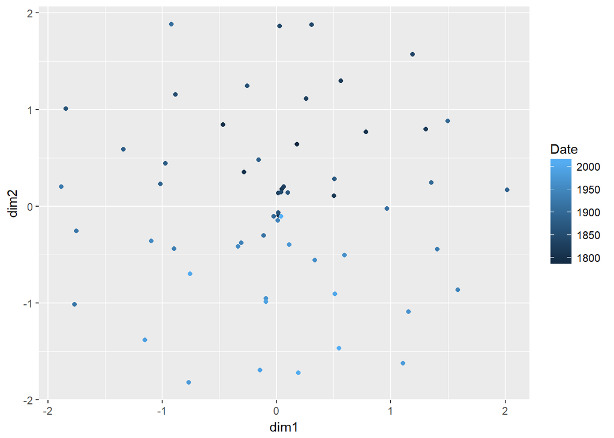

```r
plot_df <- cbind(as.data.frame(tsne$Y),as.Date(speech_list$Date,format='%m/%d/%Y'))
names(plot_df) <- c('dim1','dim2','Date')
ggplot(plot_df)+
  geom_point(mapping=aes(x=dim1,y=dim2,color=Date))
```

In the graph, we could found that the lighter points (more recent speeches) and the dark points (older speeches) are in different position. If we set some break point in the time, based on the graph, we could easily separate the points of different period speeches. Note that, for t-sne, the absolute position is meatless, but the relative positions of the points matter. This shows that the speeches are actually evolved over time and there is a trend in inaugural speeches.

To see more about the trend we could plot out the word-cloud in different time period in America history.

## Interactive visualize important words in different period.

```r
Period <- as.character(timeline$Period)
shinyApp(
    ui = fluidPage(
      fluidRow(style = "padding-bottom: 20px;",
        column(4, selectInput('period', 'Period', Period , selected=Period[1] )),
        column(4, sliderInput('nwords', 'Number of words', 3, min = 20,
                              max = 200, value=100, step = 20))
      ),
      fluidRow(
        plotOutput('wordclouds', height = "400px")
      )
    ),

    server = function(input, output, session) {
      # Combine the selected variables into a new data frame
      selectedData <- reactive({
        list(dtm.term=tidy(dtm[speech_list$Period==input$period,])$term,
             dtm.count=tidy(dtm[speech_list$Period==input$period,])$count
             )
      })

      output$wordclouds <- renderPlot(height = 400, {
        par(mfrow=c(1,1), mar = c(0, 0, 3, 0))
        wordcloud(selectedData()$dtm.term,
                  selectedData()$dtm.count,
              scale=c(4,0.5),
              max.words=input$nwords,
              min.freq=1,
              random.order=FALSE,
              rot.per=0,
              use.r.layout=FALSE,
              random.color=FALSE,
              colors=brewer.pal(10,"Blues"),
            main=input$speech1)
      })
    },

    options = list(height = 600)
)
```

Shiny applications not supported in static R Markdown documents

# Step 6 - LDA

To see more about the speeches’ relevance and difference, we could cluster on the topics of what the speeches are mainly about. Here we need LDA to obtain the topic distribution of each speech.

## Topic model training

```r
dtm <- DocumentTermMatrix(docs) # use word counts as the elements of the matrix
burnin <- 4000
iter <- 2000
thin <- 500
seed <-list(2003,5,63,100001,765)
nstart <- 5
best <- TRUE

#Number of topics
k <- 10

#Run LDA using Gibbs sampling
ldaOut <-LDA(dtm, k, method="Gibbs", control=list(nstart=nstart,
                                                 seed = seed, best=best,
                                                 burnin = burnin, iter = iter,
                                                 thin=thin))

ldaOut.terms <- as.matrix(terms(ldaOut,10))
ldaOut.terms
```

```
##       Topic 1    Topic 2      Topic 3   Topic 4        Topic 5
##  [1,] "war"      "government" "will"    "power"        "upon"
##  [2,] "commerce" "will"       "new"     "constitution" "service"
##  [3,] "limits"   "people"     "nation"  "executive"    "shall"
##  [4,] "equal"    "states"     "people"  "spirit"       "people"
##  [5,] "nature"   "may"        "world"   "can"          "american"
##  [6,] "union"    "country"    "america" "upon"         "power"
##  [7,] "force"    "great"      "can"     "institutions" "give"
##  [8,] "fellow"   "public"     "let"     "never"        "confidence"
##  [9,] "honor"    "every"      "time"    "liberty"      "republic"
## [10,] "peace"    "citizens"   "one"     "union"        "expect"
##       Topic 6   Topic 7       Topic 8    Topic 9        Topic 10
##  [1,] "world"   "upon"        "things"   "constitution" "must"
##  [2,] "nations" "will"        "men"      "union"        "freedom"
##  [3,] "must"    "business"    "shall"    "upon"         "americans"
##  [4,] "can"     "congress"    "national" "now"          "free"
##  [5,] "justice" "war"         "see"      "shall"        "citizens"
##  [6,] "peace"   "law"         "use"      "question"     "country"
##  [7,] "freedom" "secure"      "without"  "law"          "fellow"
##  [8,] "may"     "trade"       "life"     "right"        "liberty"
##  [9,] "never"   "make"        "wealth"   "can"          "hope"
## [10,] "law"     "legislation" "interest" "wisdom"       "president"
```

Here is the top word in each topic. But here we do not need care too much about the the topics are about. We just need the topic as a new representation of documents, then we could cluster based on the topic distribution.

## Adaptive kmeans

```r
set.seed(1)
# apply adaptive kmeans where number of cluster is not given
# here we use cosin distance instead of euclidean metric
akm.res <- akmeans(ldaOut@gamma,mode = 3,d.metric = 2, min.k=2)
```

```
## [1] "# of clusters violating given threshold condition:  2"
## [1] "now.k= 4"
## [1] "converged at k= 4"
```

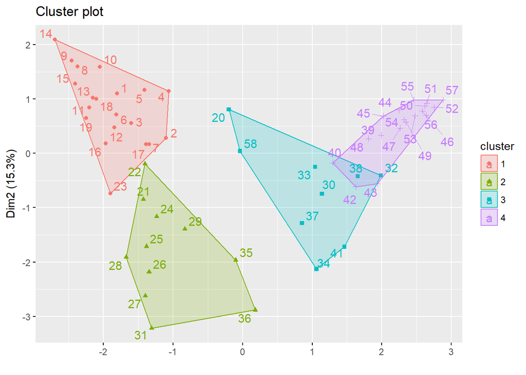

```r
# plot out the result
fviz_cluster(list(data=ldaOut@gamma,cluster=akm.res$cluster),
             repel= TRUE,
             data =ldaOut@gamma, xlab="", xaxt="n",
             show.clust.cent=FALSE)
```

The numbers in the graph correspond to the order in time of the inaugural speech. From the graph above we could see that the cluster is also mostly based on time, the smaller the number the older the speech is made. Cluster 1 is the oldest one and then cluster 2, cluster 3 and cluster 4. Also, we could find that the 58 speech is on the edge of cluster 3 which indicates that, President Trump’s inauguration speech is quite different from his recent predecessors.